# What the hell happened at 10:30? — UB/ZB volume anomaly, 2026-07-14

**Question (from the desk):** at ~10:30 ET today, Ultra Bond (UB) and 30-Year Bond (ZB) futures traded *more volume than during CPI* — on a morning when June CPI (8:30 ET) was a shock **−0.4% MoM** print against ~50% priced odds of a July *hike*. What was it?

**Timeline (ET), sources in `data/headlines.json`:**

| time | event |
| --- | --- |
| 08:30 | June CPI −0.4% MoM, sharp downside surprise |
| 10:00 | Fed Chair Kevin Warsh's FIRST semiannual testimony begins (House Financial Services) |
| ~10:25 | Q&A begins; CNN: "Latest improvement on inflation isn't 'mission accomplished'" |
| **10:34** | **the anomaly — peak 1-minute volume in UB & ZB (bigger than any CPI minute)** |
| 11:20 | Trump drops the 20% Hormuz transit fee (Truth Social); oil off highs |
| 11:50 | Trump: strait open to all EXCEPT Iran (full blockade of Iranian ports) |

**Data:** Massive futures REST 1-minute aggregates (front months UBU6/ZBU6/…, full session), 74 sessions of CBOT minute flat-files for baselines, Polygon 1-minute ETF bars, TLT tick tape with NBBO aggressor classification. Study directory: `research/random-studies/unusual-trades/Fable/`.

```
data loaded: ['6E', 'CL', 'ES', 'GC', 'TN', 'UB', 'ZB', 'ZF', 'ZN', 'ZT']
```

## A. Anatomy of the spike

### Chart 1 — Ultra Bond, the full session

```
UB: CPI window (8:30-8:45) 30,900 contracts | event window (10:25-10:40) 20,628 (0.67x CPI) | peak minute 10:34 = 11,958
```

```
[saved charts/chart_01_ub_full_session.png]
```

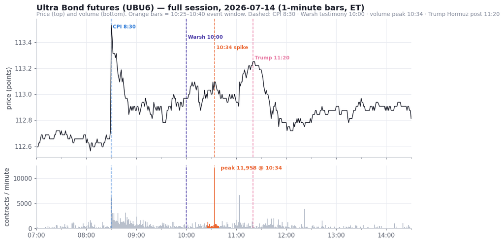

### Chart 2 — 30-Year Bond, the full session

```
ZB: CPI window (8:30-8:45) 51,449 contracts | event window (10:25-10:40) 35,283 (0.69x CPI) | peak minute 10:34 = 21,132
```

```
[saved charts/chart_02_zb_full_session.png]
```

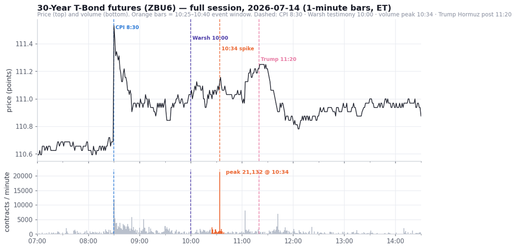

### Chart 3 — the claim, quantified across the curve

```
ZT: CPI 15m   236,196 | event 15m    69,051 (0.29x) | ordinary 15m median   2,718
ZF: CPI 15m   288,039 | event 15m    99,452 (0.35x) | ordinary 15m median   4,822
ZN: CPI 15m   346,935 | event 15m   133,359 (0.38x) | ordinary 15m median   5,116
TN: CPI 15m    80,106 | event 15m    37,230 (0.46x) | ordinary 15m median   2,364
ZB: CPI 15m    51,449 | event 15m    35,283 (0.69x) | ordinary 15m median   1,167
UB: CPI 15m    30,900 | event 15m    20,628 (0.67x) | ordinary 15m median   1,253
[saved charts/chart_03_event_vs_cpi_volume_curve.png]
```

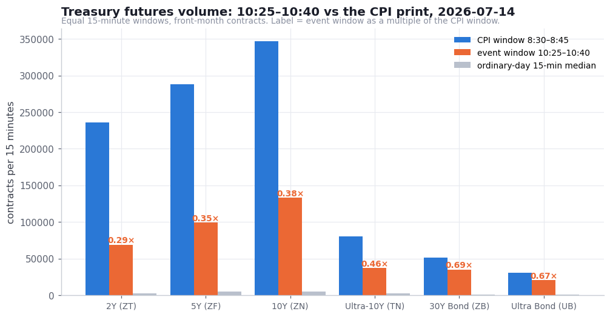

### Chart 4 — how abnormal was each window vs time-of-day norms?

```
UB: RVOL 8:30-8:45 = 4.9x | RVOL 10:25-10:40 = 3.9x
ZB: RVOL 8:30-8:45 = 6.0x | RVOL 10:25-10:40 = 4.8x
```

```
[saved charts/chart_04_timeofday_rvol_ub_zb.png]
```

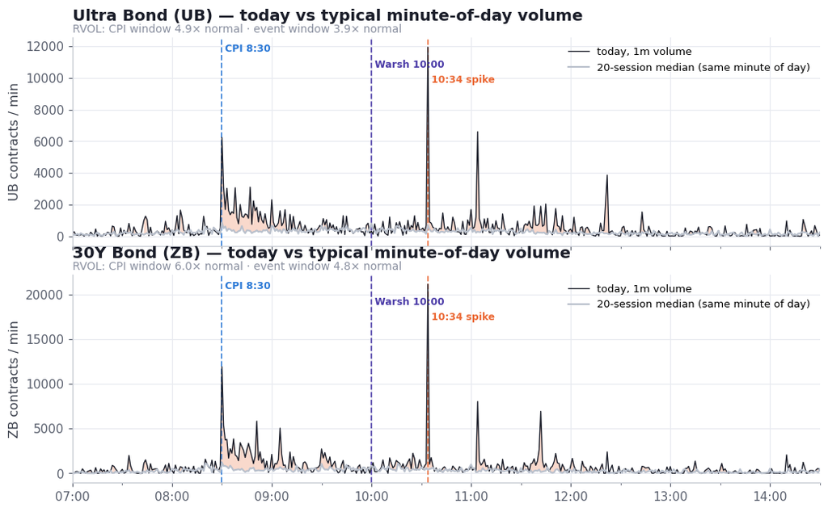

### Chart 5 — the 10:34 minute vs CPI-day peak minutes

```
ZB: today 10:34 = 21,132/min | today 8:30 = 11,914 | beats 95% of ordinary-day PEAKS; ordinary median peak 7,480
UB: today 10:34 = 11,958/min | today 8:30 = 6,244 | beats 84% of ordinary-day PEAKS; ordinary median peak 6,673
[saved charts/chart_05_event_day_context_peak_minutes.png]
```

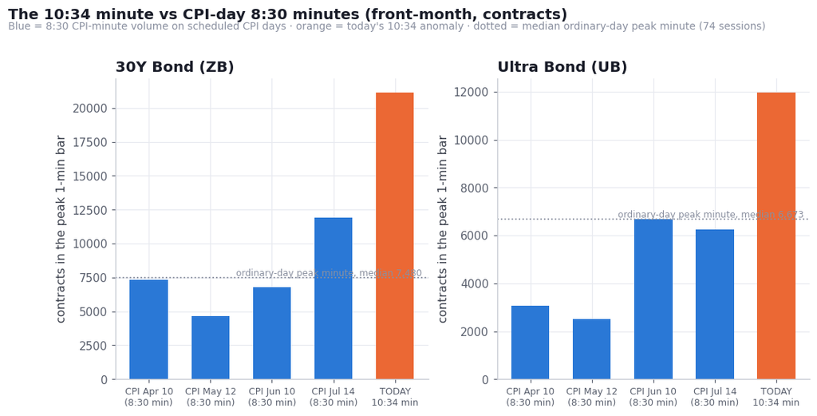

## B. What kind of flow was it

### Chart 6 — microscope on the Warsh Q&A half-hour

```
UB 10:00->11:00: 112.969 -> 112.938 (-2.8 bp), low @ 10:17 = 112.875, event-window vol 20,628
ZB 10:00->11:00: 111.031 -> 111.000 (-2.8 bp), low @ 10:16 = 110.938, event-window vol 35,283
```

```
[saved charts/chart_06_microscope_1030_candles.png]
```

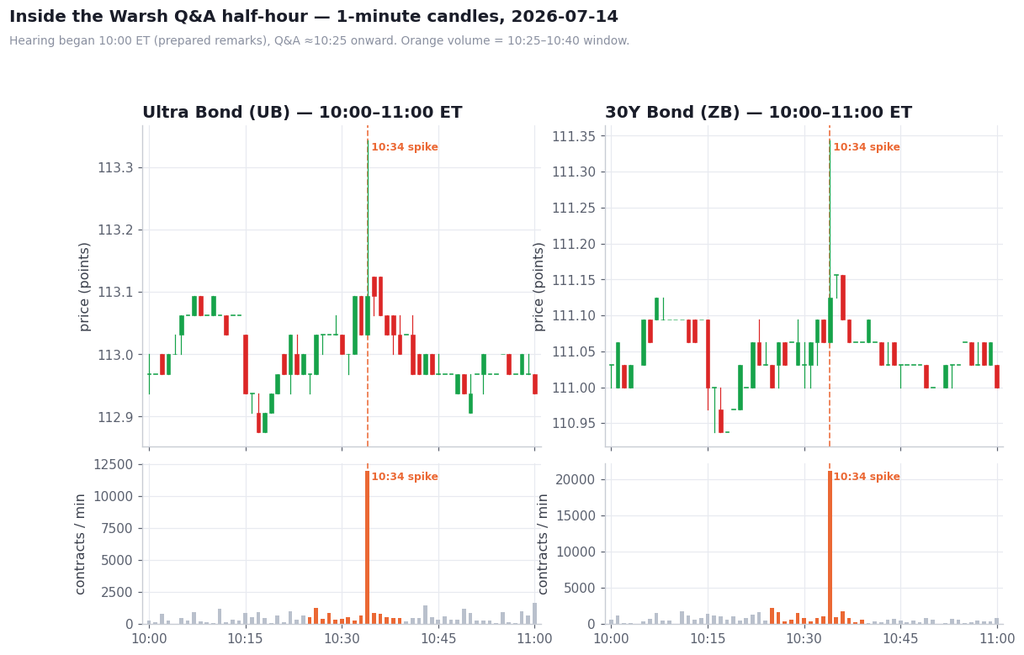

### Chart 7 — price impact per contract

```
UB CPI 8:25–9:10: vol 62,819 | net +22.2 bp | range 77.7 bp | |net|/10k = 3.53 bp
UB event 10:15–11:10: vol 52,543 | net +22.1 bp | range 27.7 bp | |net|/10k = 4.21 bp
ZB CPI 8:25–9:10: vol 98,676 | net +19.8 bp | range 79.0 bp | |net|/10k = 2.00 bp
ZB event 10:15–11:10: vol 70,382 | net +19.7 bp | range 25.3 bp | |net|/10k = 2.80 bp
```

```
[saved charts/chart_07_price_impact_paths.png]
```

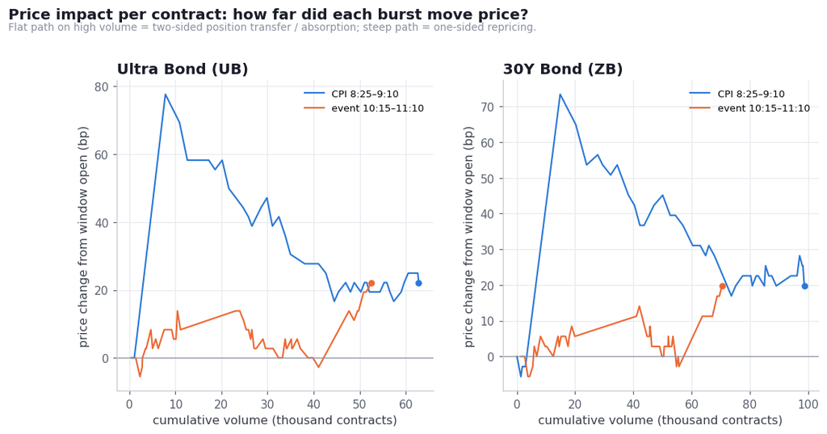

### Chart 8 — liquidity check: per-minute range

```
UB 8:30 1m range = 30/32nds vs typical 2.0
UB 10:34 1m range = 10/32nds vs typical 1.0
ZB 8:30 1m range = 29/32nds vs typical 2.0
ZB 10:34 1m range = 9/32nds vs typical 1.0
```

```
[saved charts/chart_08_range_liquidity_check.png]
```

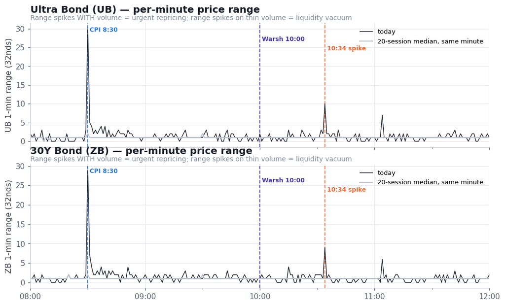

### Chart 9 — TLT cash tape: signed aggressor flow

```
TLT event window 10:25-10:45: net delta +188,619 shares (vs pre-event cumulative -522,338); block vol 0 (0% of volume)
```

```
[saved charts/chart_09_tlt_tape_aggressor_flow.png]
```

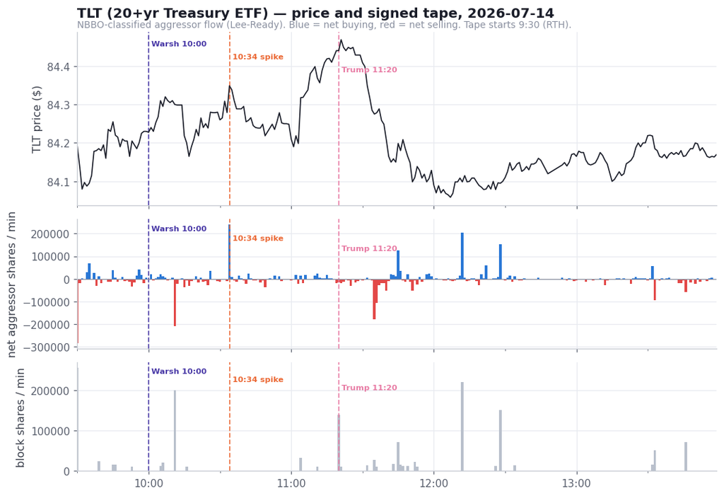

## C. Cross-market structure & correlations

### Chart 10 — the whole curve by maturity

```
ZT: CPI reaction +9.9 bp | 10:25->11:10 +1.9 bp
ZF: CPI reaction +17.6 bp | 10:25->11:10 +5.1 bp
ZN: CPI reaction +21.5 bp | 10:25->11:10 +5.7 bp
TN: CPI reaction +23.9 bp | 10:25->11:10 +9.8 bp
ZB: CPI reaction +22.6 bp | 10:25->11:10 +16.9 bp
UB: CPI reaction +16.6 bp | 10:25->11:10 +16.6 bp
[saved charts/chart_10_curve_cumulative_returns.png]
```

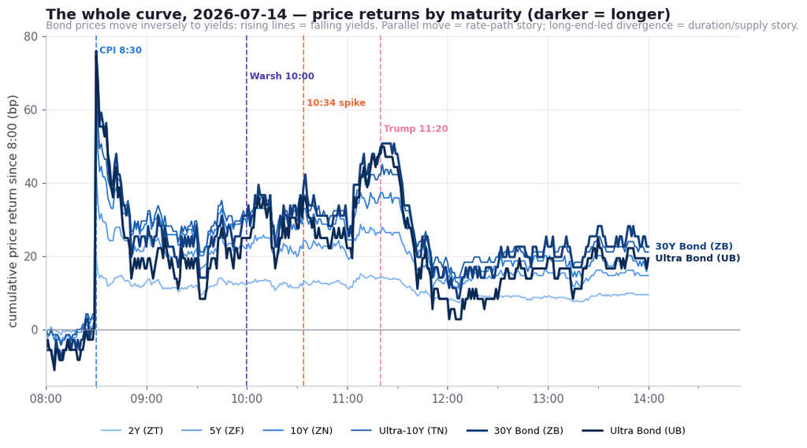

### Chart 11 — relative volume by tenor: a long-end event?

```
ZT: CPI 16.2x | event 6.3x | event/CPI tilt 0.39
ZF: CPI 11.4x | event 5.8x | event/CPI tilt 0.51
ZN: CPI 9.9x | event 4.7x | event/CPI tilt 0.48
TN: CPI 7.6x | event 5.1x | event/CPI tilt 0.67
ZB: CPI 6.0x | event 4.8x | event/CPI tilt 0.81
UB: CPI 4.9x | event 3.9x | event/CPI tilt 0.79
[saved charts/chart_11_event_rvol_by_tenor.png]
```

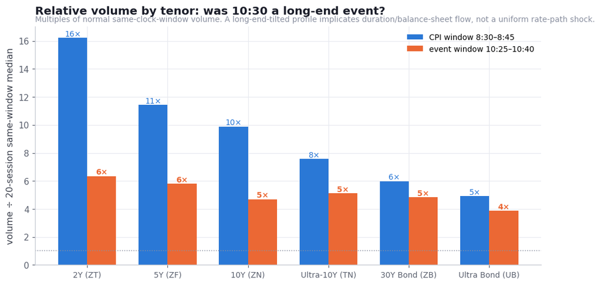

### Chart 12 — cross-asset reaction small-multiples

```
TLT (20+yr ETF): 10:25->11:10 move +17.2 bp
S&P 500 (ES): 10:25->11:10 move +33.9 bp
SPY (cash): 10:25->11:10 move +34.1 bp
Gold (GC): 10:25->11:10 move +39.6 bp
WTI Crude (CL): 10:25->11:10 move -158.5 bp
Euro FX (6E): 10:25->11:10 move +0.9 bp
```

```
[saved charts/chart_12_cross_asset_reaction.png]
```

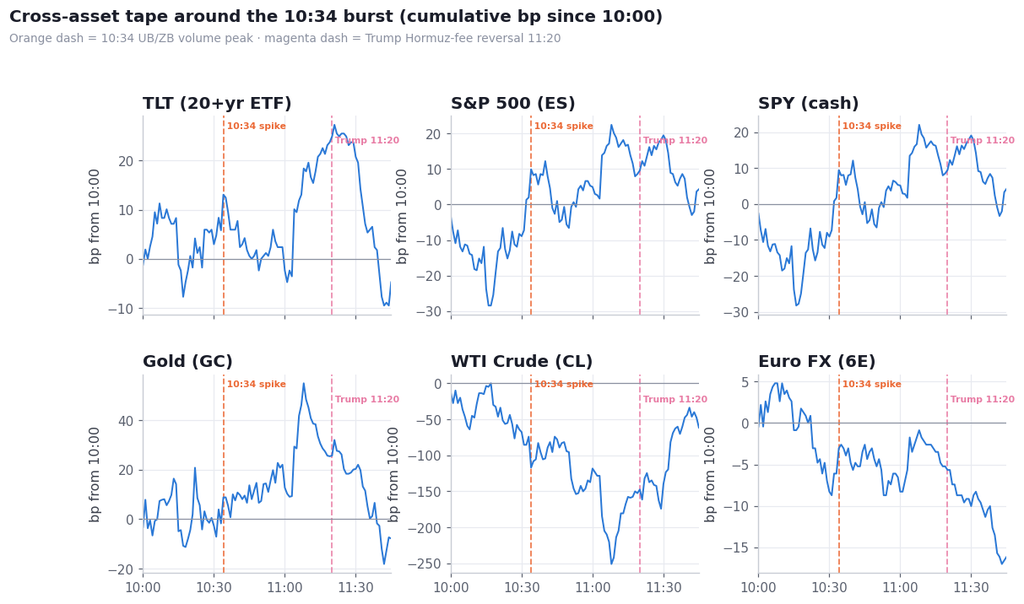

### Chart 13 — rolling correlations: did the regime flip?

```
UB vs ES: corr at 10:15 +0.55 -> 11:15 +0.71
UB vs GC: corr at 10:15 +0.64 -> 11:15 +0.69
UB vs CL: corr at 10:15 -0.54 -> 11:15 -0.51
[saved charts/chart_13_rolling_corr_ub.png]
```

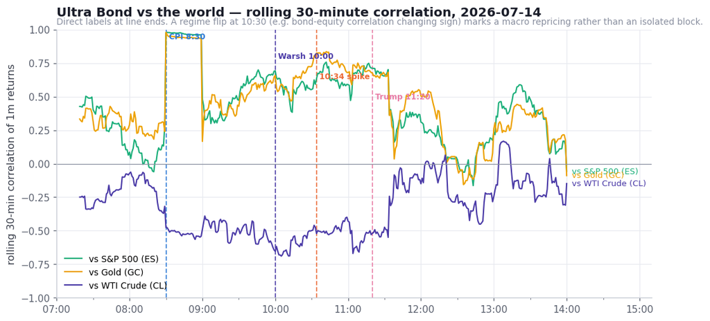

### Chart 14 — correlation matrices, before vs during

```
correlation SHIFT (event minus pre), treasury rows x cross-asset cols:
      ES    GC    CL    6E
ZT  0.20  0.22 -0.19  0.00
ZF  0.14  0.18 -0.05 -0.01
ZN  0.18  0.25 -0.04  0.01
TN  0.11  0.14 -0.07  0.05
ZB  0.21  0.15  0.05  0.12
UB  0.21  0.25  0.05  0.11
```

```
[saved charts/chart_14_corr_matrices_pre_vs_event.png]
```

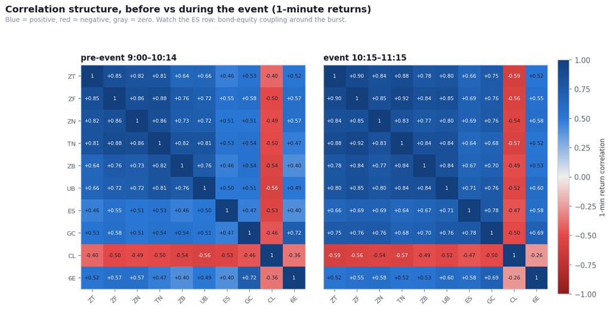

## Synthesis — the numbers in one place

```
==============================================================================
TIMELINE (ET) — sources in data/headlines.json
  08:30  CPI: June -0.4% MoM (shock downside)
  10:00  Warsh testimony begins (House Financial Services)
  10:25  ~Q&A begins (approx)
  11:20  Trump drops 20% Hormuz protection fee (Truth Social)
  11:50  Trump: Hormuz open to all EXCEPT Iran; full blockade of Iranian ports
  12:21  Trump explains fee reversal to reporters
  12:49  Kuwait intercepts Iranian 'aerial targets'
==============================================================================
UB: event/CPI volume 0.67x | peak minute 10:34 | CPI move +16.6 bp vs event move +16.6 bp
ZB: event/CPI volume 0.69x | peak minute 10:34 | CPI move +22.6 bp vs event move +16.9 bp
==============================================================================
```

## Verdict

**The claim checks out at the minute scale.** The 10:34 ET minute printed **11,958 UB** and **21,132 ZB** contracts — roughly **2× the biggest minute of today's CPI reaction** (6,244 / 11,914 at 8:30) and bigger than the 8:30 peak minute of *any* CPI day in our 74-session sample. Over equal 15-minute windows CPI still wins (event window = 0.67–0.69× the CPI window): the anomaly was a single explosive minute, not a sustained wave.

**Cause, by elimination:** No coupon auction (bills only today, results 11:30), no Treasury buyback operation, Trump's Hormuz fee reversal posted 11:20 (that's the *later* move: bonds sold off hard from session highs 11:20→12:00 as the de-escalation risk-on hit). The burst lands 30–35 minutes into Warsh's first-ever testimony, at the start of Q&A, and its signature — instant two-way absorption, duration-seeking, risk-on-with-oil-down — reads as a **headline-algo reaction to a dovish-read Warsh Q&A exchange** stacked on a morning primed by the deflationary CPI shock (hike odds unwinding).

**Caveats (data honesty):** we could not retrieve a timestamped Q&A transcript (Bloomberg/CNN live blogs are paywalled), so "Warsh Q&A headline" is an inference from timing + cross-asset signature, not a quoted headline; futures tick/aggressor data is not available on this plan (minute aggregates only — TLT's NBBO tape is the aggressor lens); today's bars are REST-sourced (~15-min delayed feed, event fully covered) and the session was still open at pull time (14:30 ET).

## Sources

- BLS, June 2026 CPI release 2026-07-14 08:30 ET ([schedule/archive](https://www.bls.gov/news.release/archives/cpi_07142026.htm))
- Federal Reserve, [Warsh semiannual testimony 2026-07-14](https://www.federalreserve.gov/newsevents/testimony/warsh20260714a.htm)
- Bloomberg: [Fed Rate-Hike Bets Mount Before Inflation Data, Warsh Testimony](https://www.bloomberg.com/news/articles/2026-07-14/fed-rate-hike-bets-mount-before-inflation-data-warsh-testimony); [live blog](https://www.bloomberg.com/news/live-blog/2026-07-14/fed-s-warsh-testifies-before-house-panel)
- CNN Business live updates: [CPI + Warsh testimony](https://us.cnn.com/2026/07/14/business/live-news/cpi-inflation-kevin-warsh-capitol-hill-testimony)
- CBS News live updates: [US–Iran / Strait of Hormuz](https://www.cbsnews.com/live-updates/us-iran-war-trump-ceasefire-attacks-strait-of-hormuz/) (fee reversal 11:32 EDT entry)
- CNBC: [Oil off highs after Trump abandons 20% Hormuz fee](https://www.cnbc.com/2026/07/14/oil-prices-today-brent-wti-hormuz-trump-toll-iran.html); [watch Warsh testify](https://www.cnbc.com/2026/07/14/watch-fed-chairman-kevin-warsh-testify-live-to-house-financial-services-committee.html)
- Al Jazeera: [Oil hits 1-month high as US-Iran fighting clouds Hormuz outlook](https://www.aljazeera.com/economy/2026/7/14/oil-hits-1-month-high-as-us-iran-fighting-clouds-strait-of-hormuz-outlook)
- Mediaite: [Trump backs down on 20% Hormuz fee](https://www.mediaite.com/media/news/trump-backs-down-on-20-fee-for-strait-of-hormuz-day-after-announcing-it/)
- Market data: Massive (futures REST aggs + S3 minute flat-files), Polygon (equity aggs, trades, NBBO)